# Activity Monitoring Data

Download the dataset from the following link and read the data.

```r
if(!file.exists("activity.csv")) {
  download.file("https://d396qusza40orc.cloudfront.net/repdata%2Fdata%2Factivity.zip", "zipfile.zip", method = "curl")
  unzip("zipfile.zip")
  }
data <- read.csv("activity.csv", header = TRUE, sep = ",")
```

```r
head(data)
```

```
##   steps       date interval
## 1    NA 2012-10-01        0
## 2    NA 2012-10-01        5
## 3    NA 2012-10-01       10
## 4    NA 2012-10-01       15
## 5    NA 2012-10-01       20
## 6    NA 2012-10-01       25
```

Keep the list of vectors

```r
allDates <- unique(as.Date(data$date))
interval <- unique(data$interval)
```

### 1.1 What is mean total number of steps taken per day?

```r
# First split up the data frame for steps by day
stepsSplit <- split(data$steps, allDates)

# Next find the total number of steps over each day
totalStepsPerDay <- sapply(stepsSplit, sum, na.rm=TRUE)
totalStepsPerDay
```

```
## 2012-10-01 2012-10-02 2012-10-03 2012-10-04 2012-10-05 2012-10-06
##       9048       8678       7184       8716       9912       8208
## 2012-10-07 2012-10-08 2012-10-09 2012-10-10 2012-10-11 2012-10-12
##       8047       9408       8744       7780       9898      10296
## 2012-10-13 2012-10-14 2012-10-15 2012-10-16 2012-10-17 2012-10-18
##       8167       9154      10189       8720      10610      11388
## 2012-10-19 2012-10-20 2012-10-21 2012-10-22 2012-10-23 2012-10-24
##      10709      12036      10334      11461      10490      10071
## 2012-10-25 2012-10-26 2012-10-27 2012-10-28 2012-10-29 2012-10-30
##       8671      10072      11524      10791      10819      10046
## 2012-10-31 2012-11-01 2012-11-02 2012-11-03 2012-11-04 2012-11-05
##       9147       9134       8739       9626       8987       9369
## 2012-11-06 2012-11-07 2012-11-08 2012-11-09 2012-11-10 2012-11-11
##       9752       9777       9789      10480      10493      10334
## 2012-11-12 2012-11-13 2012-11-14 2012-11-15 2012-11-16 2012-11-17
##      11045      10686      10829       9073       8746       9925
## 2012-11-18 2012-11-19 2012-11-20 2012-11-21 2012-11-22 2012-11-23
##      10609       8043       9821       8224       7675       8354
## 2012-11-24 2012-11-25 2012-11-26 2012-11-27 2012-11-28 2012-11-29
##       8617       7197       7627       6064       6481       7025
## 2012-11-30
##       7769
```

### 1.2 Make a histogram of the total number of steps taken each day

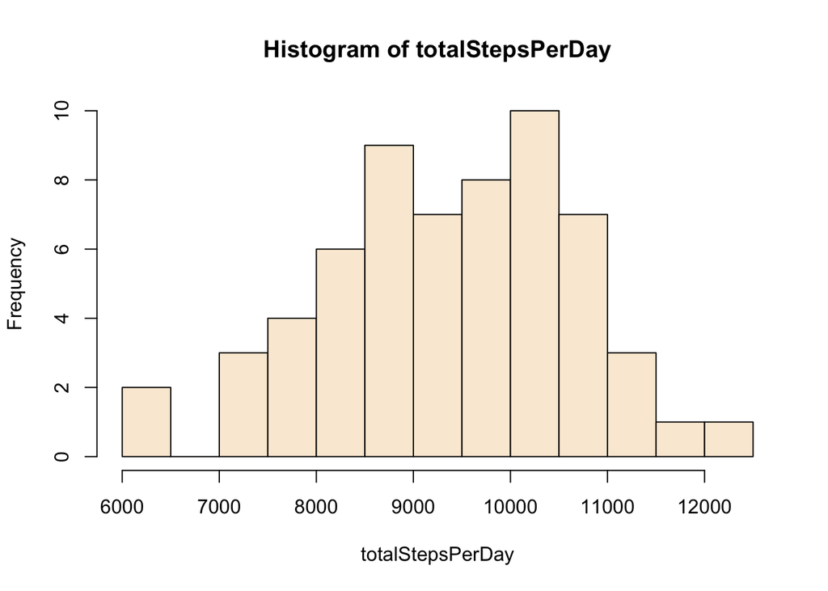

```r
hist(totalStepsPerDay, breaks = 20, col = "antiquewhite")
```

### 1.3 Calculate and report the mean and median of the total number of steps taken per day

```r
meanStepsPerDay <- sapply(stepsSplit, mean, na.rm =  TRUE)
medianStepsPerDay <- sapply(stepsSplit, median, na.rm =  TRUE)
meanStepsPerDay
```

```
## 2012-10-01 2012-10-02 2012-10-03 2012-10-04 2012-10-05 2012-10-06
##   36.04781   34.57371   28.62151   34.86400   39.64800   32.70120
## 2012-10-07 2012-10-08 2012-10-09 2012-10-10 2012-10-11 2012-10-12
##   32.05976   37.48207   34.97600   31.12000   39.59200   41.18400
## 2012-10-13 2012-10-14 2012-10-15 2012-10-16 2012-10-17 2012-10-18
##   32.66800   36.61600   40.75600   34.74104   42.27092   45.55200
## 2012-10-19 2012-10-20 2012-10-21 2012-10-22 2012-10-23 2012-10-24
##   42.83600   48.14400   41.33600   45.84400   42.12851   40.44578
## 2012-10-25 2012-10-26 2012-10-27 2012-10-28 2012-10-29 2012-10-30
##   34.82329   40.44980   46.28112   43.33735   43.27600   40.18400
## 2012-10-31 2012-11-01 2012-11-02 2012-11-03 2012-11-04 2012-11-05
##   36.58800   36.53600   35.09639   38.65863   36.09237   37.47600
## 2012-11-06 2012-11-07 2012-11-08 2012-11-09 2012-11-10 2012-11-11
##   39.00800   39.10800   39.15600   41.92000   41.97200   41.33600
## 2012-11-12 2012-11-13 2012-11-14 2012-11-15 2012-11-16 2012-11-17
##   44.18000   42.74400   43.14343   36.29200   34.98400   39.54183
## 2012-11-18 2012-11-19 2012-11-20 2012-11-21 2012-11-22 2012-11-23
##   42.26693   32.04382   39.12749   32.76494   30.57769   33.28287
## 2012-11-24 2012-11-25 2012-11-26 2012-11-27 2012-11-28 2012-11-29
##   34.33068   28.67331   30.38645   24.15936   25.82072   27.98805
## 2012-11-30
##   30.95219
```

```r
medianStepsPerDay
```

```
## 2012-10-01 2012-10-02 2012-10-03 2012-10-04 2012-10-05 2012-10-06
##          0          0          0          0          0          0
## 2012-10-07 2012-10-08 2012-10-09 2012-10-10 2012-10-11 2012-10-12
##          0          0          0          0          0          0
## 2012-10-13 2012-10-14 2012-10-15 2012-10-16 2012-10-17 2012-10-18
##          0          0          0          0          0          0
## 2012-10-19 2012-10-20 2012-10-21 2012-10-22 2012-10-23 2012-10-24
##          0          0          0          0          0          0
## 2012-10-25 2012-10-26 2012-10-27 2012-10-28 2012-10-29 2012-10-30
##          0          0          0          0          0          0
## 2012-10-31 2012-11-01 2012-11-02 2012-11-03 2012-11-04 2012-11-05
##          0          0          0          0          0          0
## 2012-11-06 2012-11-07 2012-11-08 2012-11-09 2012-11-10 2012-11-11
##          0          0          0          0          0          0
## 2012-11-12 2012-11-13 2012-11-14 2012-11-15 2012-11-16 2012-11-17
##          0          0          0          0          0          0
## 2012-11-18 2012-11-19 2012-11-20 2012-11-21 2012-11-22 2012-11-23
##          0          0          0          0          0          0
## 2012-11-24 2012-11-25 2012-11-26 2012-11-27 2012-11-28 2012-11-29
##          0          0          0          0          0          0
## 2012-11-30
##          0
```

### 2.1 Make a time series plot (i.e. type = “l”) of the 5-minute interval (x-axis) and the average number of steps taken, averaged across all days (y-axis)

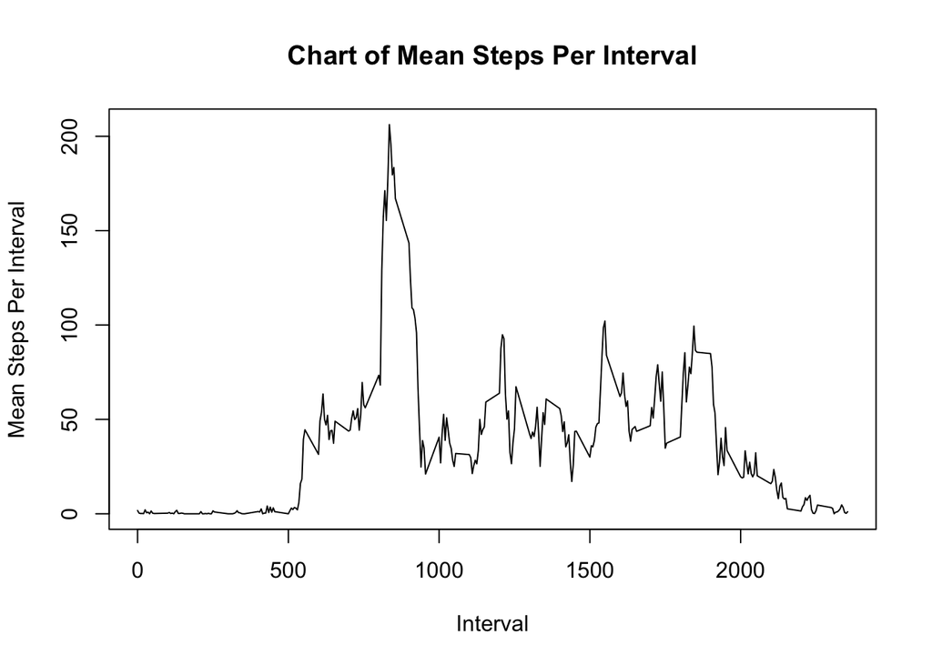

```r
# First split up the data frame for steps by interval
stepsSplitInterval <- split(data$steps, interval)
# Then calculate average steps per interval
meanStepsPerInterval <- sapply(stepsSplitInterval, mean, na.rm =  TRUE)
#Time to make a plot!
plot(interval, meanStepsPerInterval, type = "l", xlab = "Interval", ylab = "Mean Steps Per Interval", main = "Chart of Mean Steps Per Interval")
```

### 2.2 Which 5-minute interval, on average across all the days in the dataset, contains the maximum number of steps?

```r
which.max(meanStepsPerInterval)
```

```
## 835
## 104
```

### 3.1 Calculate and report the total number of missing values in the dataset (i.e. the total number of rows with NAs)

```r
isna <- is.na(data$steps)
sum(isna)
```

```
## [1] 2304
```

### 3.2 Devise a strategy for filling in all of the missing values in the dataset. The strategy does not need to be sophisticated. For example, you could use the mean/median for that day, or the mean for that 5-minute interval, etc.

```r
meanStepsPerInterval[is.nan(meanStepsPerInterval)] <- 0 #coerce NAN value into 0
meanColumn <- rep(meanStepsPerInterval, 288)               #create a column repeating by 288 times
rawSteps <- data$steps
stepsNA <- is.na(rawSteps)                              #find NA values
rawSteps[stepsNA] <- meanColumn[stepsNA]                #replace NA value with mean steps per day
```

### 3.3 Create a new dataset that is equal to the original dataset but with the missing data filled in.

```r
dataNew <- data
dataNew$steps <- rawSteps
```

### 3.4 Make a histogram of the total number of steps taken each day and Calculate and report the mean and median total number of steps taken per day. Do these values differ from the estimates from the first part of the assignment? What is the impact of imputing missing data on the estimates of the total daily number of steps?

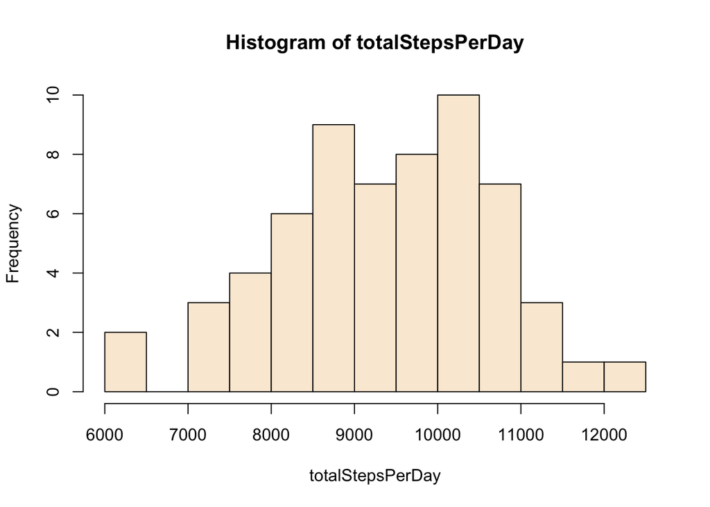

```r
stepsSplitNew <- split(dataNew$steps, allDates)
totalStepsPerDayNew <- sapply(stepsSplitNew, sum)
par(mfrow = c(1,1))
hist(totalStepsPerDay, breaks = 20, col = "antiquewhite")
```

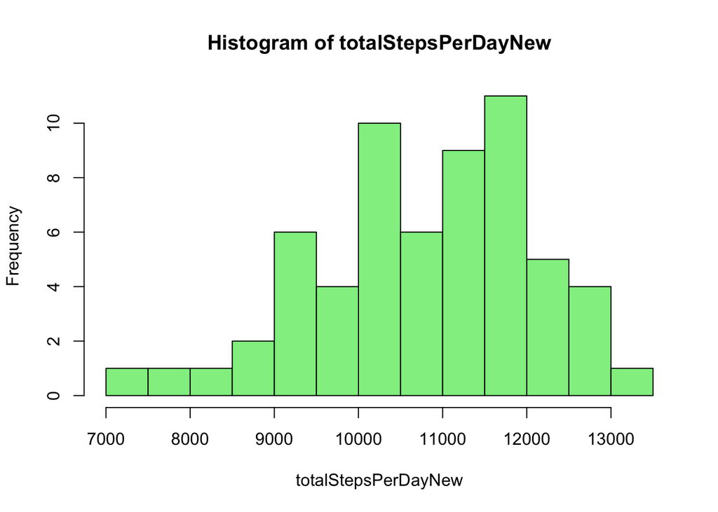

```r
hist(totalStepsPerDayNew, breaks = 20, col = "lightgreen")
```

```r
meanStepsPerDayNew <- sapply(stepsSplitNew, mean)
medianStepsPerDayNew <- sapply(stepsSplitNew, median)

meanStepsPerDay
```

```
## 2012-10-01 2012-10-02 2012-10-03 2012-10-04 2012-10-05 2012-10-06
##   36.04781   34.57371   28.62151   34.86400   39.64800   32.70120
## 2012-10-07 2012-10-08 2012-10-09 2012-10-10 2012-10-11 2012-10-12
##   32.05976   37.48207   34.97600   31.12000   39.59200   41.18400
## 2012-10-13 2012-10-14 2012-10-15 2012-10-16 2012-10-17 2012-10-18
##   32.66800   36.61600   40.75600   34.74104   42.27092   45.55200
## 2012-10-19 2012-10-20 2012-10-21 2012-10-22 2012-10-23 2012-10-24
##   42.83600   48.14400   41.33600   45.84400   42.12851   40.44578
## 2012-10-25 2012-10-26 2012-10-27 2012-10-28 2012-10-29 2012-10-30
##   34.82329   40.44980   46.28112   43.33735   43.27600   40.18400
## 2012-10-31 2012-11-01 2012-11-02 2012-11-03 2012-11-04 2012-11-05
##   36.58800   36.53600   35.09639   38.65863   36.09237   37.47600
## 2012-11-06 2012-11-07 2012-11-08 2012-11-09 2012-11-10 2012-11-11
##   39.00800   39.10800   39.15600   41.92000   41.97200   41.33600
## 2012-11-12 2012-11-13 2012-11-14 2012-11-15 2012-11-16 2012-11-17
##   44.18000   42.74400   43.14343   36.29200   34.98400   39.54183
## 2012-11-18 2012-11-19 2012-11-20 2012-11-21 2012-11-22 2012-11-23
##   42.26693   32.04382   39.12749   32.76494   30.57769   33.28287
## 2012-11-24 2012-11-25 2012-11-26 2012-11-27 2012-11-28 2012-11-29
##   34.33068   28.67331   30.38645   24.15936   25.82072   27.98805
## 2012-11-30
##   30.95219
```

```r
meanStepsPerDayNew
```

```
## 2012-10-01 2012-10-02 2012-10-03 2012-10-04 2012-10-05 2012-10-06
##   36.19176   34.87389   29.52948   35.10725   39.15107   33.06650
## 2012-10-07 2012-10-08 2012-10-09 2012-10-10 2012-10-11 2012-10-12
##   32.76756   37.46181   35.31473   31.97812   39.19444   40.15586
## 2012-10-13 2012-10-14 2012-10-15 2012-10-16 2012-10-17 2012-10-18
##   32.94340   36.70493   40.06132   34.75753   41.41745   44.34061
## 2012-10-19 2012-10-20 2012-10-21 2012-10-22 2012-10-23 2012-10-24
##   41.49849   45.91450   40.10010   43.90638   40.96502   39.83707
## 2012-10-25 2012-10-26 2012-10-27 2012-10-28 2012-10-29 2012-10-30
##   34.74378   39.69739   45.06263   42.61052   42.76192   40.12127
## 2012-10-31 2012-11-01 2012-11-02 2012-11-03 2012-11-04 2012-11-05
##   36.86609   36.67911   35.37697   38.53059   36.13044   37.40428
## 2012-11-06 2012-11-07 2012-11-08 2012-11-09 2012-11-10 2012-11-11
##   38.98401   38.79488   38.80045   41.43809   41.46135   41.07396
## 2012-11-12 2012-11-13 2012-11-14 2012-11-15 2012-11-16 2012-11-17
##   43.84126   42.62041   42.85043   37.10174   36.16726   40.02699
## 2012-11-18 2012-11-19 2012-11-20 2012-11-21 2012-11-22 2012-11-23
##   42.09814   33.03964   39.24502   33.61013   31.57737   33.73388
## 2012-11-24 2012-11-25 2012-11-26 2012-11-27 2012-11-28 2012-11-29
##   34.74915   30.02372   31.44340   25.80896   27.18737   29.49306
## 2012-11-30
##   31.94366
```

```r
medianStepsPerDay
```

```
## 2012-10-01 2012-10-02 2012-10-03 2012-10-04 2012-10-05 2012-10-06
##          0          0          0          0          0          0
## 2012-10-07 2012-10-08 2012-10-09 2012-10-10 2012-10-11 2012-10-12
##          0          0          0          0          0          0
## 2012-10-13 2012-10-14 2012-10-15 2012-10-16 2012-10-17 2012-10-18
##          0          0          0          0          0          0
## 2012-10-19 2012-10-20 2012-10-21 2012-10-22 2012-10-23 2012-10-24
##          0          0          0          0          0          0
## 2012-10-25 2012-10-26 2012-10-27 2012-10-28 2012-10-29 2012-10-30
##          0          0          0          0          0          0
## 2012-10-31 2012-11-01 2012-11-02 2012-11-03 2012-11-04 2012-11-05
##          0          0          0          0          0          0
## 2012-11-06 2012-11-07 2012-11-08 2012-11-09 2012-11-10 2012-11-11
##          0          0          0          0          0          0
## 2012-11-12 2012-11-13 2012-11-14 2012-11-15 2012-11-16 2012-11-17
##          0          0          0          0          0          0
## 2012-11-18 2012-11-19 2012-11-20 2012-11-21 2012-11-22 2012-11-23
##          0          0          0          0          0          0
## 2012-11-24 2012-11-25 2012-11-26 2012-11-27 2012-11-28 2012-11-29
##          0          0          0          0          0          0
## 2012-11-30
##          0
```

```r
medianStepsPerDayNew
```

```
## 2012-10-01 2012-10-02 2012-10-03 2012-10-04 2012-10-05 2012-10-06
##          0          0          0          0          0          0
## 2012-10-07 2012-10-08 2012-10-09 2012-10-10 2012-10-11 2012-10-12
##          0          0          0          0          0          0
## 2012-10-13 2012-10-14 2012-10-15 2012-10-16 2012-10-17 2012-10-18
##          0          0          0          0          0          0
## 2012-10-19 2012-10-20 2012-10-21 2012-10-22 2012-10-23 2012-10-24
##          0          0          0          0          0          0
## 2012-10-25 2012-10-26 2012-10-27 2012-10-28 2012-10-29 2012-10-30
##          0          0          0          0          0          0
## 2012-10-31 2012-11-01 2012-11-02 2012-11-03 2012-11-04 2012-11-05
##          0          0          0          0          0          0
## 2012-11-06 2012-11-07 2012-11-08 2012-11-09 2012-11-10 2012-11-11
##          0          0          0          0          0          0
## 2012-11-12 2012-11-13 2012-11-14 2012-11-15 2012-11-16 2012-11-17
##          0          0          0          0          0          0
## 2012-11-18 2012-11-19 2012-11-20 2012-11-21 2012-11-22 2012-11-23
##          0          0          0          0          0          0
## 2012-11-24 2012-11-25 2012-11-26 2012-11-27 2012-11-28 2012-11-29
##          0          0          0          0          0          0
## 2012-11-30
##          0
```

### 4.1 Create a new factor variable in the dataset with two levels – “weekday” and “weekend” indicating whether a given date is a weekday or weekend day.

```r
weekend <- c("Saturday", "Sunday")              #create a vector weekend for later validation
dataNew$isweekend <- weekdays(as.POSIXlt(as.character(dataNew$date))) %in% weekend  #check if the date belongs to weekend
dataNew$isweekend <- as.numeric(dataNew$isweekend) #'1' means weekend '0' means weekday
```

### 4.2 Make a panel plot containing a time series plot (i.e. type = “l”) of the 5-minute interval (x-axis) and the average number of steps taken, averaged across all weekday days or weekend days (y-axis).

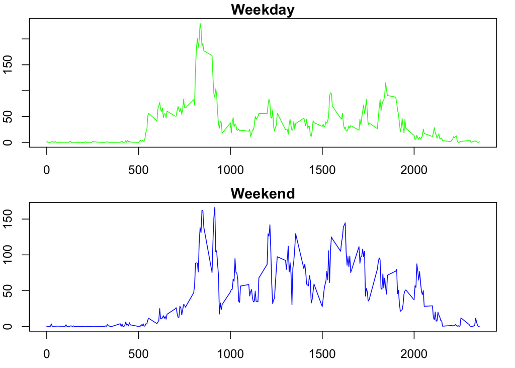

```r
dataNew_weekday <- dataNew[which(dataNew$isweekend == 0),] #create dataset only consist weekday data
dataNew_weekend <- dataNew[which(dataNew$isweekend == 1),] #create dataset only consist weekend data

stepsSplitWeekday <- split(dataNew_weekday$steps, dataNew_weekday$interval)
meanStepsPerIntervalWeekday <- sapply(stepsSplitWeekday, mean)

stepsSplitWeekend <- split(dataNew_weekend$steps, dataNew_weekend$interval)
meanStepsPerIntervalWeekend <- sapply(stepsSplitWeekend, mean)

par(mfrow = c(2,1), mai = c(0.5,0.4,0.25,0.25))
plot(unique(dataNew_weekday$interval), meanStepsPerIntervalWeekday, type = "l", main = "Weekday", xlab = "", ylab = "", col = "green")
plot(unique(dataNew_weekend$interval), meanStepsPerIntervalWeekend, type = "l", main = "Weekend", xlab = "Interval", ylab = "",  col = "blue")
```

Average steps of Weekday clearly become flattter than Weekend after the 1000th interval.